# Distribuições de Poisson e binomial negativa

Gabriela Neres, Mariane Melo, Pedro Lopes

## 1 Introdução

Os rios são ecossistemas extremamente ricos em biodiversidade que estão sofrendo com diversos impactos em função das ações humanas, como transformação da paisagem, construção de paisagens e substração de água (Dudgeon et al., 2006). Outro impacto comum é o regime de fluxo. Rios intermitentes (cujo fluxo cessa em algum período do ano) costumam ter menos biodiversidade local em relação aos perenes por causa dos impactos causados pela interrupção do fluxo (dessecação, aumento de temperatura) (Datry et al., 2014)

O objetivo neste exercício será modelar a riqueza de espécies em função do regime de fluxo e de impactos antrópicos. A base de dados utilizada contabiliza a riqueza de macroinvertebrados aquáticos em trechos de rio.

## 2 Carregando os pacotes

```r
library(tidyverse) # Ferramentas de manipulação e visualização de dados
library(performance) # Validação dos modelos
library(DHARMa) # Validação dos modelos
library(MASS) # Modelo binomial negativo
library(GGally) # Análise exploratória
library(sjPlot) # Efeitos condicionais
library(patchwork) # Ferramentas gráficas
```

## 3 Carregando os dados

```r
df <- read.csv("df.csv")

glimpse(df)
```

```
## Rows: 259
## Columns: 15
## $ cd_site                   <int> 6000890, 6000990, 6000997, 6001180, 6001190,…
## $ richness                  <int> 58, 39, 58, 44, 39, 51, 45, 48, 57, 42, 48, …
## $ month                     <int> 8, 8, 8, 7, 7, 4, 4, 4, 4, 4, 7, 7, 4, 4, 4,…
## $ year                      <int> 2021, 2021, 2021, 2021, 2021, 2021, 2021, 20…
## $ x                         <int> 913808, 930888, 923751, 896770, 905207, 9277…
## $ y                         <int> 6763319, 6781191, 6761653, 6750896, 6750556,…
## $ rang_corr                 <int> 3, 2, 3, 3, 4, 4, 3, 2, 4, 4, 3, 2, 3, 5, 4,…
## $ attr_inter                <dbl> 0.040, 0.118, 0.026, 0.060, 0.078, 0.042, 0.…
## $ PCT_EXTENSIVE_AGRICULTURE <dbl> 40.850107, 20.255165, 25.349586, 50.747940, …
## $ PCT_INTENSIVE_AGRICULTURE <dbl> 15.03680, 3.38250, 23.96671, 17.87466, 15.54…
## $ PCT_URBAN                 <dbl> 2.598770, 1.087266, 3.326116, 3.209150, 2.49…
## $ DRAIN2017                 <dbl> 0.066783758, 0.003577713, 0.030757721, 0.088…
## $ ROADS_R                   <dbl> 0.000000, 0.000000, 0.000000, 0.000000, 0.00…
## $ DYKES_R                   <dbl> 0.000000, 0.000000, 0.000000, 0.000000, 0.00…
## $ RIPAR30M_R                <dbl> 40.7787018, 90.5523987, 34.9334984, 22.16970…
```

cd_site: id do local amostrado; richness: riqueza; month: mês de coleta; year: ano de coleta; rang_corr: ordem do rio; attr_inter: nível de intermitência do rio; pct_near_natural-pct_urban: métricas de paisagem a 1km2 à montante do rio; DRAIN2017: drenagem de água; ROADS_R: construção de estradas nas proximidades; DYKES_R: barragens próximas; RIPAR30M_R: proporção de mata ripária 30m ao redor do ponto de amostragem.

## 4 Análise exploratória dos dados

```r
ggpairs(df[,-c(1, 4)])
```

[figure not shown]

Apesar de várias variáveis apresentarem algum grau de correlação, nenhuma foi acima de 70%. Portanto, vamos inicialmente trabalhar com todas elas, e realizar uma avaliação a posteriori pelo fator de inflação de variância (VIF).

## 5 Distribuição de Poisson

Vamos ajustar um modelo contendo somente as variáveis de interesse (impactos antrópicos e intermitência) e avaliar os resíduos.

```r
m.poiss <- glm(richness ~ attr_inter + PCT_INTENSIVE_AGRICULTURE + PCT_EXTENSIVE_AGRICULTURE + PCT_URBAN + DRAIN2017 + ROADS_R + DYKES_R + RIPAR30M_R, data = df, family = poisson(link = "log"))

check_model(m.poiss)
```

[figure not shown]

```r
m.poiss2 <- glm(richness ~ attr_inter + PCT_INTENSIVE_AGRICULTURE + PCT_EXTENSIVE_AGRICULTURE + PCT_URBAN + DRAIN2017 + ROADS_R + DYKES_R + RIPAR30M_R + rang_corr + month, data = df, family = poisson(link = "log"))

check_model(m.poiss2)
```

[figure not shown]

```r
check_overdispersion(m.poiss2)
```

```
## # Overdispersion test
##
##        dispersion ratio =   2.851
##   Pearson's Chi-Squared = 707.134
##                 p-value = < 0.001
```

O modelo ainda apresenta algum problema na especificação da dispersão e no padrão dos resíduos. Vamos checar a autocorrelação espacial.

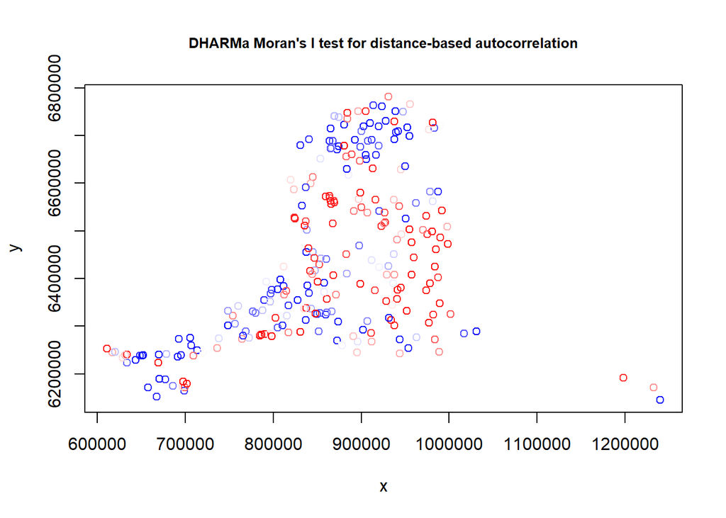

```
##
##  DHARMa Moran's I test for distance-based autocorrelation
##
## data:  sim.res.m.poiss2
## observed = 0.099913, expected = -0.003876, sd = 0.010642, p-value <
## 2.2e-16
## alternative hypothesis: Distance-based autocorrelation
```

```r
sim.res.m.poiss2 <- simulateResiduals(m.poiss2, n = 1000)
testSpatialAutocorrelation(sim.res.m.poiss2, x = df$x, y = df$y)
```

O modelo apresenta autocorrelação espacial. Vamos acrescentar longitude e latitude para tentarmos corrigir.

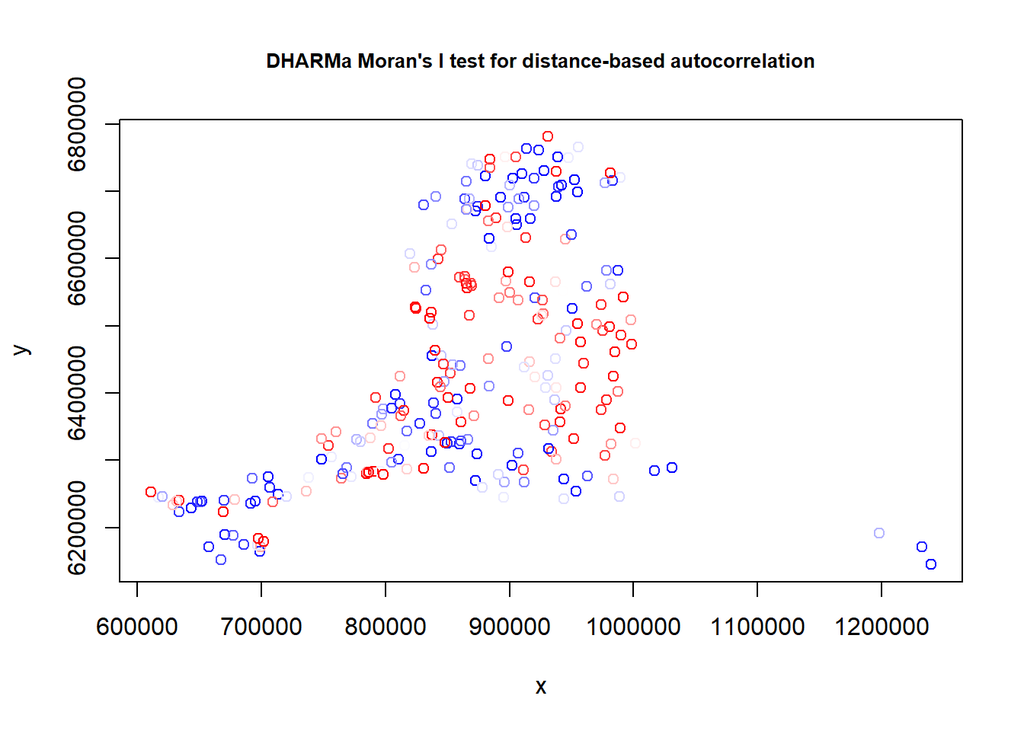

```
##
##  DHARMa Moran's I test for distance-based autocorrelation
##
## data:  sim.res.m.poiss3
## observed = 0.076734, expected = -0.003876, sd = 0.010640, p-value =
## 3.553e-14
## alternative hypothesis: Distance-based autocorrelation
```

```r
m.poiss3 <- glm(richness ~ attr_inter + PCT_INTENSIVE_AGRICULTURE + PCT_EXTENSIVE_AGRICULTURE + PCT_URBAN + DRAIN2017 + ROADS_R + DYKES_R + RIPAR30M_R + rang_corr + month + x*y, data = df, family = poisson(link = "log"))

sim.res.m.poiss3 <- simulateResiduals(m.poiss3, n = 1000)
testSpatialAutocorrelation(sim.res.m.poiss3, x = df$x, y = df$y)
```

Adicionar latitude e longitude não corrige a autocorrelação espacial… Vamos simplificar o modelo aplicando uma redução por AIC.

```r
stepAIC(m.poiss3)
```

```
## Start:  AIC=2108.22
## richness ~ attr_inter + PCT_INTENSIVE_AGRICULTURE + PCT_EXTENSIVE_AGRICULTURE +
##     PCT_URBAN + DRAIN2017 + ROADS_R + DYKES_R + RIPAR30M_R +
##     rang_corr + month + x * y
##
##                             Df Deviance    AIC
## - attr_inter                 1   677.95 2106.2
## - RIPAR30M_R                 1   678.17 2106.4
## - DRAIN2017                  1   678.22 2106.5
## - DYKES_R                    1   678.44 2106.7
## <none>                           677.95 2108.2
## - PCT_EXTENSIVE_AGRICULTURE  1   680.45 2108.7
## - x:y                        1   683.47 2111.7
## - PCT_INTENSIVE_AGRICULTURE  1   685.06 2113.3
## - rang_corr                  1   692.60 2120.9
## - PCT_URBAN                  1   696.50 2124.8
## - ROADS_R                    1   698.15 2126.4
## - month                      1   738.96 2167.2
##
## Step:  AIC=2106.23
## richness ~ PCT_INTENSIVE_AGRICULTURE + PCT_EXTENSIVE_AGRICULTURE +
##     PCT_URBAN + DRAIN2017 + ROADS_R + DYKES_R + RIPAR30M_R +
##     rang_corr + month + x + y + x:y
##
##                             Df Deviance    AIC
## - RIPAR30M_R                 1   678.17 2104.4
## - DRAIN2017                  1   678.23 2104.5
## - DYKES_R                    1   678.44 2104.7
## <none>                           677.95 2106.2
## - PCT_EXTENSIVE_AGRICULTURE  1   680.54 2106.8
## - x:y                        1   683.49 2109.8
## - PCT_INTENSIVE_AGRICULTURE  1   688.20 2114.5
## - rang_corr                  1   693.52 2119.8
## - PCT_URBAN                  1   697.80 2124.1
## - ROADS_R                    1   698.19 2124.5
## - month                      1   739.08 2165.3
##
## Step:  AIC=2104.44
## richness ~ PCT_INTENSIVE_AGRICULTURE + PCT_EXTENSIVE_AGRICULTURE +
##     PCT_URBAN + DRAIN2017 + ROADS_R + DYKES_R + rang_corr + month +
```

[output cut: 28 more lines]

```
## - month                      1   740.00 2162.3
##
## Step:  AIC=2101.19
## richness ~ PCT_INTENSIVE_AGRICULTURE + PCT_EXTENSIVE_AGRICULTURE +
##     PCT_URBAN + ROADS_R + rang_corr + month + x + y + x:y
##
##                             Df Deviance    AIC
## <none>                           678.92 2101.2
## - PCT_EXTENSIVE_AGRICULTURE  1   681.41 2101.7
## - x:y                        1   684.24 2104.5
## - rang_corr                  1   695.02 2115.3
## - PCT_INTENSIVE_AGRICULTURE  1   695.21 2115.5
## - PCT_URBAN                  1   700.19 2120.5
## - ROADS_R                    1   715.84 2136.1
## - month                      1   741.08 2161.4
```

```
##
## Call:  glm(formula = richness ~ PCT_INTENSIVE_AGRICULTURE + PCT_EXTENSIVE_AGRICULTURE +
##     PCT_URBAN + ROADS_R + rang_corr + month + x + y + x:y, family = poisson(link = "log"),
##     data = df)
##
## Coefficients:
##               (Intercept)  PCT_INTENSIVE_AGRICULTURE
##                -1.160e+01                 -2.320e-03
## PCT_EXTENSIVE_AGRICULTURE                  PCT_URBAN
##                -1.864e-03                 -5.492e-03
##                   ROADS_R                  rang_corr
##                -1.026e-03                  3.848e-02
##                     month                          x
##                 5.211e-02                  1.149e-05
##                         y                        x:y
##                 2.478e-06                 -1.973e-12
##
## Degrees of Freedom: 258 Total (i.e. Null);  249 Residual
## Null Deviance:       956.6
## Residual Deviance: 678.9     AIC: 2101
```

```r
p.simpl1 <- glm(richness ~ PCT_INTENSIVE_AGRICULTURE + PCT_EXTENSIVE_AGRICULTURE +
    PCT_URBAN + ROADS_R + rang_corr + month + x + y + x:y, family = poisson(link = "log"),
    data = df) # AIC = 2101.19

p.simpl2 <- glm(richness ~ PCT_INTENSIVE_AGRICULTURE + PCT_EXTENSIVE_AGRICULTURE +
    PCT_URBAN + ROADS_R + DYKES_R + rang_corr + month + x + y +
    x:y, family = poisson(link = "log"),
    data = df) # AIC = 2102.8

check_model(p.simpl1)
```

[figure not shown]

```r
check_model(p.simpl2)
```

[figure not shown]

Ambos os modelos apresentaram um ajuste semelhante, então vamos prosseguir com o mais simples.

```r
summary(p.simpl1)
```

```
##
## Call:
## glm(formula = richness ~ PCT_INTENSIVE_AGRICULTURE + PCT_EXTENSIVE_AGRICULTURE +
##     PCT_URBAN + ROADS_R + rang_corr + month + x + y + x:y, family = poisson(link = "log"),
##     data = df)
##
## Coefficients:
##                             Estimate Std. Error z value Pr(>|z|)
## (Intercept)               -1.160e+01  4.928e+00  -2.354  0.01856 *
## PCT_INTENSIVE_AGRICULTURE -2.320e-03  5.757e-04  -4.030 5.57e-05 ***
## PCT_EXTENSIVE_AGRICULTURE -1.864e-03  1.183e-03  -1.576  0.11510
## PCT_URBAN                 -5.492e-03  1.230e-03  -4.465 8.00e-06 ***
## ROADS_R                   -1.026e-03  2.014e-04  -5.097 3.45e-07 ***
## rang_corr                  3.848e-02  9.567e-03   4.022 5.77e-05 ***
## month                      5.211e-02  6.631e-03   7.859 3.88e-15 ***
## x                          1.149e-05  5.363e-06   2.143  0.03212 *
## y                          2.478e-06  7.887e-07   3.142  0.00168 **
## x:y                       -1.973e-12  8.563e-13  -2.304  0.02120 *
## ---
## Signif. codes:  0 '***' 0.001 '**' 0.01 '*' 0.05 '.' 0.1 ' ' 1
##
## (Dispersion parameter for poisson family taken to be 1)
##
##     Null deviance: 956.63  on 258  degrees of freedom
## Residual deviance: 678.92  on 249  degrees of freedom
## AIC: 2101.2
##
## Number of Fisher Scoring iterations: 4
```

E avaliar os efeitos condicionais:

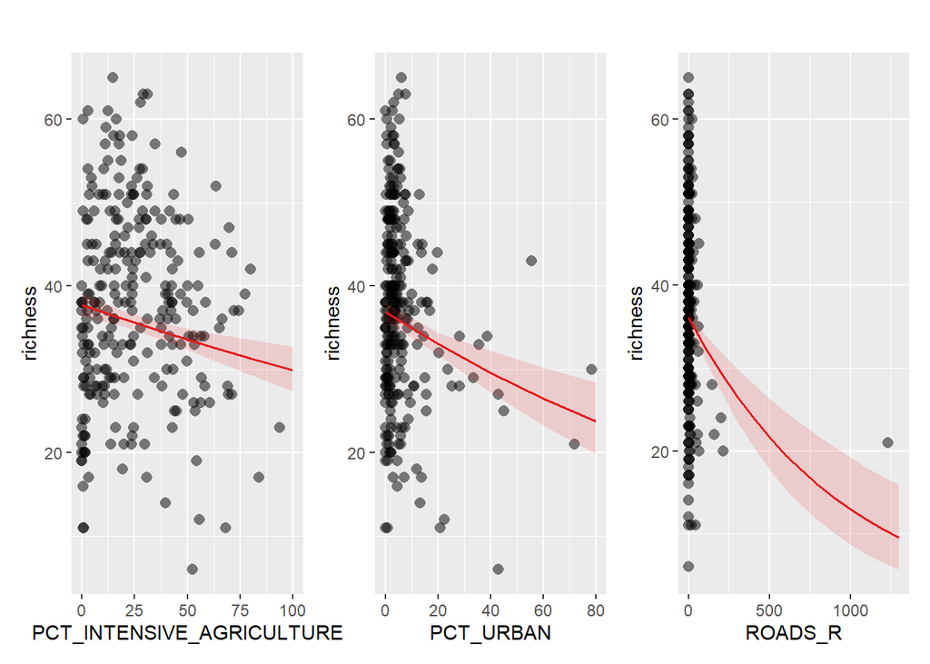

```r
plot_model(p.simpl1, type = "pred", terms = "PCT_INTENSIVE_AGRICULTURE", show.data = T, title = "") +
  plot_model(p.simpl1, type = "pred", terms = "PCT_URBAN", show.data = T, title = "") +
  plot_model(p.simpl1, type = "pred", terms = "ROADS_R", show.data = T, title = "")
```

Tanto os impactos na paisagem (conversão de área natural para agricultura intensiva e urbanização) quanto danos locais reduzem significantemente a riqueza!

## 6 Distribuição binomial negativa

Vamos testar se o modelo se ajusta melhor com a distribuição binomial negativa.

```r
m.negbin <- glm.nb(richness ~ attr_inter + PCT_INTENSIVE_AGRICULTURE + PCT_EXTENSIVE_AGRICULTURE + PCT_URBAN + DRAIN2017 + ROADS_R + DYKES_R + RIPAR30M_R + rang_corr + month + x*y, data = df)

check_model(m.negbin)
```

[figure not shown]

```r
check_overdispersion(m.negbin)
```

```
## # Overdispersion test
##
##  dispersion ratio = 0.915
##           p-value = 0.312
```

Com a distribuição binomial negativa, os resíduos se mostram mais uniformes e não houve superdispersão. Vamos aplicar a redução do modelo.

```r
stepAIC(m.negbin)
```

```
## Start:  AIC=1952.3
## richness ~ attr_inter + PCT_INTENSIVE_AGRICULTURE + PCT_EXTENSIVE_AGRICULTURE +
##     PCT_URBAN + DRAIN2017 + ROADS_R + DYKES_R + RIPAR30M_R +
##     rang_corr + month + x * y
##
##                             Df    AIC
## - attr_inter                 1 1950.3
## - DRAIN2017                  1 1950.4
## - DYKES_R                    1 1950.4
## - RIPAR30M_R                 1 1950.4
## - PCT_EXTENSIVE_AGRICULTURE  1 1950.9
## <none>                         1952.3
## - PCT_INTENSIVE_AGRICULTURE  1 1953.0
## - x:y                        1 1953.2
## - rang_corr                  1 1955.7
## - PCT_URBAN                  1 1957.3
## - ROADS_R                    1 1958.4
## - month                      1 1976.1
##
## Step:  AIC=1950.34
## richness ~ PCT_INTENSIVE_AGRICULTURE + PCT_EXTENSIVE_AGRICULTURE +
##     PCT_URBAN + DRAIN2017 + ROADS_R + DYKES_R + RIPAR30M_R +
##     rang_corr + month + x + y + x:y
##
##                             Df    AIC
## - DRAIN2017                  1 1948.4
## - DYKES_R                    1 1948.5
## - RIPAR30M_R                 1 1948.5
## - PCT_EXTENSIVE_AGRICULTURE  1 1948.9
## <none>                         1950.3
## - x:y                        1 1951.3
## - PCT_INTENSIVE_AGRICULTURE  1 1951.8
## - rang_corr                  1 1953.8
## - PCT_URBAN                  1 1955.5
## - ROADS_R                    1 1956.4
## - month                      1 1974.3
##
## Step:  AIC=1948.42
## richness ~ PCT_INTENSIVE_AGRICULTURE + PCT_EXTENSIVE_AGRICULTURE +
##     PCT_URBAN + ROADS_R + DYKES_R + RIPAR30M_R + rang_corr +
```

[output cut: 41 more lines]

```
## - ROADS_R                    1 1956.7
## - month                      1 1969.0
##
## Step:  AIC=1943.23
## richness ~ PCT_INTENSIVE_AGRICULTURE + PCT_URBAN + ROADS_R +
##     rang_corr + month + x + y + x:y
##
##                             Df    AIC
## <none>                         1943.2
## - x:y                        1 1943.8
## - PCT_INTENSIVE_AGRICULTURE  1 1946.4
## - rang_corr                  1 1947.4
## - PCT_URBAN                  1 1948.8
## - ROADS_R                    1 1955.3
## - month                      1 1967.3
```

```
##
## Call:  glm.nb(formula = richness ~ PCT_INTENSIVE_AGRICULTURE + PCT_URBAN +
##     ROADS_R + rang_corr + month + x + y + x:y, data = df, init.theta = 22.33189936,
##     link = log)
##
## Coefficients:
##               (Intercept)  PCT_INTENSIVE_AGRICULTURE
##                -1.225e+01                 -2.154e-03
##                 PCT_URBAN                    ROADS_R
##                -5.178e-03                 -9.554e-04
##                 rang_corr                      month
##                 4.057e-02                  5.549e-02
##                         x                          y
##                 1.301e-05                  2.556e-06
##                       x:y
##                -2.193e-12
##
## Degrees of Freedom: 258 Total (i.e. Null);  250 Residual
## Null Deviance:       376.3
## Residual Deviance: 271.2     AIC: 1945
```

```r
m.negbin.2 <- glm.nb(richness ~ PCT_INTENSIVE_AGRICULTURE + PCT_URBAN + ROADS_R +
    rang_corr + month + x + y + x:y, data = df)

check_model(m.negbin.2)
```

[figure not shown]

```r
check_overdispersion(m.negbin.2)
```

```
## # Overdispersion test
##
##  dispersion ratio = 0.919
##           p-value = 0.336
```

O ajuste parece bem melhor! Finalmente, vamos verficiar os betas estimados e plotar os efeitos condicionais.

```r
summary(m.negbin.2)
```

```
##
## Call:
## glm.nb(formula = richness ~ PCT_INTENSIVE_AGRICULTURE + PCT_URBAN +
##     ROADS_R + rang_corr + month + x + y + x:y, data = df, init.theta = 22.33189936,
##     link = log)
##
## Coefficients:
##                             Estimate Std. Error z value Pr(>|z|)
## (Intercept)               -1.225e+01  7.909e+00  -1.549 0.121495
## PCT_INTENSIVE_AGRICULTURE -2.154e-03  9.373e-04  -2.298 0.021538 *
## PCT_URBAN                 -5.178e-03  1.869e-03  -2.770 0.005598 **
## ROADS_R                   -9.554e-04  2.616e-04  -3.652 0.000261 ***
## rang_corr                  4.057e-02  1.583e-02   2.563 0.010379 *
## month                      5.549e-02  1.044e-02   5.317 1.06e-07 ***
## x                          1.301e-05  8.738e-06   1.489 0.136475
## y                          2.556e-06  1.266e-06   2.019 0.043527 *
## x:y                       -2.193e-12  1.395e-12  -1.571 0.116114
## ---
## Signif. codes:  0 '***' 0.001 '**' 0.01 '*' 0.05 '.' 0.1 ' ' 1
##
## (Dispersion parameter for Negative Binomial(22.3319) family taken to be 1)
##
##     Null deviance: 376.34  on 258  degrees of freedom
## Residual deviance: 271.18  on 250  degrees of freedom
## AIC: 1945.2
##
## Number of Fisher Scoring iterations: 1
##
##
##               Theta:  22.33
##           Std. Err.:  3.26
##
##  2 x log-likelihood:  -1925.234
```

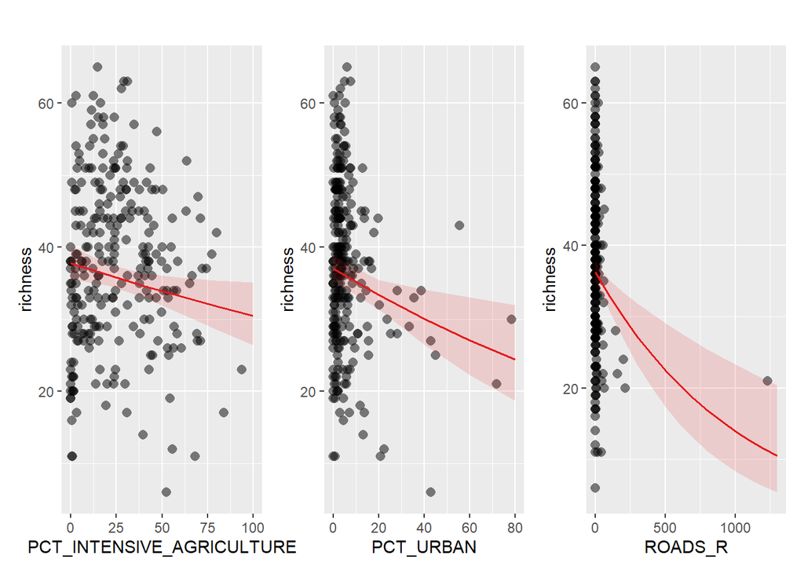

```r
plot_model(m.negbin.2, type = "pred", terms = "PCT_INTENSIVE_AGRICULTURE", show.data = T, title = "") +
  plot_model(m.negbin.2, type = "pred", terms = "PCT_URBAN", show.data = T, title = "") +
  plot_model(m.negbin.2, type = "pred", terms = "ROADS_R", show.data = T, title = "")
```

## 7 Interpretação

```r
ints.0 <- predict(m.negbin.2, newdata = data.frame(PCT_INTENSIVE_AGRICULTURE = 0, PCT_URBAN = mean(df$PCT_URBAN), ROADS_R = mean(df$ROADS_R), rang_corr = mean(df$rang_corr), month = median(df$month), x = mean(df$x), y = mean(df$y)), type = "response")

ints.1 <- predict(m.negbin.2, newdata = data.frame(PCT_INTENSIVE_AGRICULTURE = 12, PCT_URBAN = mean(df$PCT_URBAN), ROADS_R = mean(df$ROADS_R), rang_corr = mean(df$rang_corr), month = median(df$month), x = mean(df$x), y = mean(df$y)), type = "response")

ints.1 - ints.0
```

```
##         1
## -1.014481
```

A cada aumento de 12% de área de agricultura intensiva, perde-se cerca de uma espécie.

```r
urban.0 <- predict(m.negbin.2, newdata = data.frame(PCT_INTENSIVE_AGRICULTURE = mean(df$PCT_INTENSIVE_AGRICULTURE), PCT_URBAN = 0, ROADS_R = mean(df$ROADS_R), rang_corr = mean(df$rang_corr), month = median(df$month), x = mean(df$x), y = mean(df$y)), type = "response")

urban.1 <- predict(m.negbin.2, newdata = data.frame(PCT_INTENSIVE_AGRICULTURE = mean(df$PCT_INTENSIVE_AGRICULTURE), PCT_URBAN = 10, ROADS_R = mean(df$ROADS_R), rang_corr = mean(df$rang_corr), month = median(df$month), x = mean(df$x), y = mean(df$y)), type = "response")

urban.1 - urban.0
```

```
##         1
## -1.963972
```

A cada aumento de 10% de área urbana, perde-se duas espécies.

```r
roads.0 <- predict(m.negbin.2, newdata = data.frame(PCT_INTENSIVE_AGRICULTURE = mean(df$PCT_INTENSIVE_AGRICULTURE), PCT_URBAN = mean(df$PCT_URBAN), ROADS_R = 0, rang_corr = mean(df$rang_corr), month = median(df$month), x = mean(df$x), y = mean(df$y)), type = "response")

roads.1 <- predict(m.negbin.2, newdata = data.frame(PCT_INTENSIVE_AGRICULTURE = mean(df$PCT_INTENSIVE_AGRICULTURE), PCT_URBAN = mean(df$PCT_URBAN), ROADS_R = 100, rang_corr = mean(df$rang_corr), month = median(df$month), x = mean(df$x), y = mean(df$y)), type = "response")

roads.1 - roads.0
```

```
##       1
## -3.4754
```

A cada 100 metros de estrada construída próximo aos rios, perde-se mais de três espécies.

## 8 Conclusão

Impactos a nível de paisagem, como conversão de solo de áreas naturais para urbana e de agricultura intensiva, e a nível local, como construção de estradas e rodovias próximas aos rios, configuram impactos que fortemente reduzem a riqueza de espécies de macroinvertebrados aquáticos.